# Pemodelan Regresi Peubah Lag pada Data Kualitas Udara New Delhi

Koyck, Distributed Lag Model (DLM), dan Autoregressive Distributed Lag (ARDL)

# Pendahuluan

Analisis ini bertujuan memodelkan hubungan dinamis antara **AQI (Air Quality Index)** sebagai peubah dependen ($Y_t$) dengan konsentrasi **CO (Carbon Monoxide)** sebagai peubah independen ($X_t$) pada data kualitas udara Kota New Delhi. Tiga pendekatan model peubah lag akan dibandingkan, yaitu **Model Koyck**, **Distributed Lag Model (DLM)**, dan **Autoregressive Distributed Lag (ARDL)**, dengan lag optimum ditentukan berdasarkan AIC terkecil.

# 1. Persiapan Data

## Packages

```r
library(dLagM)
library(dynlm)
library(MLmetrics)
library(lmtest)
library(car)
```

## Impor & Eksplorasi Data

```r
# Impor data
data <- read.csv("C:\\Users\\syari\\Downloads\\NewDelhi_Air_quality.csv")

# Menetapkan peubah dependen (Y) dan independen (X)
data <- data.frame(Yt = data$AQI, Xt = data$CO)

str(data)
```

```
## 'data.frame':    72 obs. of  2 variables:
##  $ Yt: num  30.2 28.2 26.6 25 26 26 26 24 23 24 ...
##  $ Xt: num  199 198 199 202 205 ...
```

```r
summary(data)
```

```
##        Yt              Xt
##  Min.   :19.00   Min.   :191.9
##  1st Qu.:25.00   1st Qu.:197.4
##  Median :27.00   Median :200.3
##  Mean   :26.18   Mean   :200.1
##  3rd Qu.:28.00   3rd Qu.:203.6
##  Max.   :32.00   Max.   :208.6
```

## Pembagian Data

Data dibagi menjadi data *training* (60 observasi pertama) untuk membentuk model dan data *testing* (12 observasi terakhir) untuk menguji akurasi peramalan.

```r
# Membagi data
train <- data[1:60, ]
test <- data[61:72, ]

# Mengubah format data menjadi objek Time Series (ts)
train.ts <- ts(train)
test.ts <- ts(test)
data.ts <- ts(data)
```

# 2. Model Koyck

Model Koyck mengatasi masalah *infinite distributed lag* (pengaruh masa lalu yang tak terhingga) dengan mengasumsikan bahwa semakin jauh jarak lag, semakin kecil pengaruhnya. Melalui transformasi aljabar, efek masa lalu dari $X$ diringkas ke dalam satu peubah, yaitu $Y_{t-1}$:

$$Y_t = \alpha(1-\lambda) + \beta_0 X_t +
\lambda Y_{t-1} + V_t$$

## Pemodelan

```r
# Membangun Model Koyck
model.koyck <- koyckDlm(x = train$Xt, y = train$Yt)
summary(model.koyck)
```

```
##
## Call:
## "Y ~ (Intercept) + Y.1 + X.t"
##
## Residuals:
##     Min      1Q  Median      3Q     Max
## -1.9413 -0.8072  0.1443  0.3627  2.2528
##
## Coefficients:
##              Estimate Std. Error t value Pr(>|t|)
## (Intercept)  1.694490  10.020652   0.169    0.866
## Y.1          0.957206   0.085573  11.186 6.74e-16 ***
## X.t         -0.003441   0.057897  -0.059    0.953
## ---
## Signif. codes:  0 '***' 0.001 '**' 0.01 '*' 0.05 '.' 0.1 ' ' 1
##
## Residual standard error: 0.9756 on 56 degrees of freedom
## Multiple R-Squared: 0.8385,  Adjusted R-squared: 0.8327
## Wald test: 145.5 on 2 and 56 DF,  p-value: < 2.2e-16
##
## Diagnostic tests:
## NULL
##
##                             alpha         beta       phi
## Geometric coefficients:  39.59607 -0.003440629 0.9572056
```

Jika *p-value* dari peubah $X_t$ dan $Y_{t-1}$ lebih kecil dari 0.05, maka kedua peubah tersebut berpengaruh signifikan terhadap $Y_t$. Koefisien pada $Y_{t-1}$ mewakili parameter $\lambda$ (laju penurunan pengaruh dari waktu ke waktu).

## Peramalan

```r
# Meramalkan 12 periode ke depan
fore.koyck <- forecast(model = model.koyck, x = test$Xt, h = 12)
fore.koyck
```

```
## $forecasts
##  [1] 21.12972 21.25962 21.38397 21.50300 21.61693 21.72599 21.83038 21.92456
##  [9] 22.00897 22.08402 22.15012 22.21339
##
## $call
## forecast.koyckDlm(model = model.koyck, x = test$Xt, h = 12)
##
## attr(,"class")
## [1] "forecast.koyckDlm" "dLagM"
```

```r
# Cek akurasi (MAPE) pada data testing
mape.koyck <- MAPE(fore.koyck$forecasts, test$Yt)
cat("MAPE Model Koyck:", mape.koyck, "\n")
```

```
## MAPE Model Koyck: 0.09190158
```

# 3. Regression with Distributed Lag (DLM)

Berbeda dengan Koyck, DLM membatasi secara spesifik berapa periode memori masa lalu dari $X$ yang dilibatkan, direpresentasikan dengan parameter $q$:

$$Y_t = \alpha + \beta_0 X_t + \beta_1
X_{t-1} + \dots + \beta_q X_{t-q} + e_t$$

## Penentuan Lag Optimum

Lag optimum $q$ dicari berdasarkan nilai AIC terkecil menggunakan `finiteDLMauto()`.

```r
# Mencari lag optimum DLM
dlm.auto <- finiteDLMauto(formula = Yt ~ Xt,
                           data = data.frame(train), q.min = 1, q.max = 10,
                           model.type = "dlm", error.type = "AIC", trace = TRUE)

# Ekstraksi q optimum (AIC terkecil)
q.opt.dlm <- as.numeric(row.names(dlm.auto)[which.min(dlm.auto$AIC)])
cat("Lag Optimum DLM (q):", q.opt.dlm, "\n")
```

```
## Lag Optimum DLM (q): 10
```

## Pemodelan dengan Lag Optimum

```r
# Membangun DLM dengan lag optimum
model.dlm.opt <- dlm(x = train$Xt, y = train$Yt, q = q.opt.dlm)
summary(model.dlm.opt)
```

```
##
## Call:
## lm(formula = model.formula, data = design)
##
## Residuals:
##      Min       1Q   Median       3Q      Max
## -2.75997 -0.40163  0.05694  0.48043  2.25548
##
## Coefficients:
##              Estimate Std. Error t value Pr(>|t|)
## (Intercept) -75.20786   12.74353  -5.902 7.77e-07 ***
## x.t           0.66693    0.12002   5.557 2.31e-06 ***
## x.1           0.03520    0.20450   0.172    0.864
## x.2          -0.23128    0.20472  -1.130    0.266
## x.3           0.21455    0.21574   0.994    0.326
## x.4           0.09079    0.21443   0.423    0.674
## x.5          -0.35627    0.21812  -1.633    0.111
## x.6           0.09821    0.21522   0.456    0.651
## x.7           0.04222    0.21676   0.195    0.847
## x.8          -0.11849    0.20390  -0.581    0.565
## x.9          -0.04804    0.20221  -0.238    0.814
## x.10          0.11560    0.11665   0.991    0.328
## ---
## Signif. codes:  0 '***' 0.001 '**' 0.01 '*' 0.05 '.' 0.1 ' ' 1
##
## Residual standard error: 1.013 on 38 degrees of freedom
## Multiple R-squared:  0.864,  Adjusted R-squared:  0.8246
## F-statistic: 21.94 on 11 and 38 DF,  p-value: 3.677e-13
##
## AIC and BIC values for the model:
##        AIC      BIC
## 1 155.4755 180.3318
```

Koefisien $X_{t-k}$ yang signifikan ($p < 0.05$) menunjukkan bahwa konsentrasi CO pada lag ke-$k$ jam sebelumnya masih berpengaruh nyata terhadap AQI saat ini.

## Peramalan

```r
# Peramalan model DLM optimum
fore.dlm.opt <- forecast(model = model.dlm.opt, x = test$Xt, h = 12)
mape.dlm.opt <- MAPE(fore.dlm.opt$forecasts, test$Yt)
cat("MAPE Model DLM Optimum:", mape.dlm.opt, "\n")
```

```
## MAPE Model DLM Optimum: 0.07668751
```

# 4. Autoregressive Distributed Lag (ARDL)

Model ARDL menggabungkan pengaruh peubah independen masa lalu **dan** peubah dependen masa lalu. Pada package `dLagM` (fungsi `ardlDlm`), $p$ = panjang lag peubah independen ($X$) dan $q$ = panjang lag peubah dependen ($Y$).

## Penentuan Lag Optimum

```r
# Mencari kombinasi p dan q optimum berdasarkan AIC terkecil
model.ardl.opt.search <- ardlBoundOrders(data = data.frame(train), ic = "AIC",
                                          formula = Yt ~ Xt)

min_p <- c()
for (i in 1:6) {
  min_p[i] <- min(model.ardl.opt.search$Stat.table[[i]])
}
q_opt <- which(min_p == min(min_p, na.rm = TRUE))
p_opt <- which(model.ardl.opt.search$Stat.table[[q_opt]] ==
                 min(model.ardl.opt.search$Stat.table[[q_opt]], na.rm = TRUE))

data.frame("Lag_Y_opt(q)" = q_opt, "Lag_X_opt(p)" = p_opt,
           "AIC" = model.ardl.opt.search$min.Stat)
```

```
##   Lag_Y_opt.q. Lag_X_opt.p.      AIC
## 1            6           15 91.87271
```

## Pemodelan dengan Lag Optimum

```r
# Membangun ARDL dengan lag optimum
model.ardl.opt <- ardlDlm(formula = Yt ~ Xt, data = train, p = p_opt, q = q_opt)
summary(model.ardl.opt)
```

```
##
## Time series regression with "ts" data:
## Start = 16, End = 60
##
## Call:
## dynlm(formula = as.formula(model.text), data = data)
##
## Residuals:
##      Min       1Q   Median       3Q      Max
## -0.94982 -0.25792 -0.03149  0.29444  1.05083
##
## Coefficients:
##               Estimate Std. Error t value Pr(>|t|)
## (Intercept) -36.097864  24.503246  -1.473 0.154865
## Xt.t          0.100238   0.119662   0.838 0.411224
## Xt.1          0.154831   0.150774   1.027 0.315622
## Xt.2         -0.263002   0.146115  -1.800 0.085595 .
## Xt.3          0.108315   0.159900   0.677 0.505218
## Xt.4          0.008679   0.162524   0.053 0.957893
## Xt.5         -0.220350   0.161446  -1.365 0.186097
## Xt.6          0.462341   0.165823   2.788 0.010720 *
## Xt.7         -0.097342   0.187881  -0.518 0.609559
## Xt.8         -0.133419   0.179095  -0.745 0.464180
## Xt.9          0.159321   0.180450   0.883 0.386831
## Xt.10        -0.025529   0.190541  -0.134 0.894635
## Xt.11        -0.021260   0.172175  -0.123 0.902850
## Xt.12        -0.052994   0.157729  -0.336 0.740068
## Xt.13        -0.008729   0.145910  -0.060 0.952836
## Xt.14         0.128628   0.140046   0.918 0.368335
## Xt.15        -0.063944   0.085626  -0.747 0.463103
## Yt.1          1.021855   0.223991   4.562 0.000153 ***
## Yt.2          0.083130   0.294565   0.282 0.780419
## Yt.3         -0.077632   0.304697  -0.255 0.801256
## Yt.4         -0.012452   0.310141  -0.040 0.968335
## Yt.5         -0.372431   0.313939  -1.186 0.248152
## Yt.6         -0.060071   0.230290  -0.261 0.796634
## ---
## Signif. codes:  0 '***' 0.001 '**' 0.01 '*' 0.05 '.' 0.1 ' ' 1
##
## Residual standard error: 0.6268 on 22 degrees of freedom
## Multiple R-squared:  0.9684, Adjusted R-squared:  0.9369
## F-statistic:  30.7 on 22 and 22 DF,  p-value: 8.113e-12
```

$p$ optimum menunjukkan seberapa jauh pengaruh historis CO ($X_{t-1}, \dots, X_{t-p}$) masih relevan, sedangkan $q$ optimum menunjukkan seberapa besar ketergantungan AQI saat ini terhadap nilai AQI ($Y_{t-1}, \dots, Y_{t-q}$) di masa lalu.

## Peramalan

```r
# Peramalan model ARDL optimum
fore.ardl.opt <- forecast(model = model.ardl.opt, x = test$Xt, h = 12)
mape.ardl.opt <- MAPE(fore.ardl.opt$forecasts, test$Yt)
cat("MAPE Model ARDL Optimum:", mape.ardl.opt, "\n")
```

```
## MAPE Model ARDL Optimum: 0.08447532
```

# 5. Evaluasi Asumsi Model

Evaluasi dilakukan pada padanan (*equivalent*) setiap model optimum menggunakan `dynlm`, karena formatnya setara dengan regresi linear biasa sehingga uji asumsi standar dapat langsung diterapkan.

```r
# Padanan Koyck: Yt ~ Xt + Yt-1
dynlm.koyck <- dynlm(Yt ~ Xt + L(Yt), data = train.ts)

# Padanan DLM optimum: Yt ~ Xt + Xt-1 + ... + Xt-q
dynlm.dlm <- dynlm(Yt ~ Xt + L(Xt, 1:q.opt.dlm), data = train.ts)

# Padanan ARDL optimum: Yt ~ Xt + Xt-1..Xt-p + Yt-1..Yt-q
dynlm.ardl <- dynlm(Yt ~ Xt + L(Xt, 1:p_opt) + L(Yt, 1:q_opt), data = train.ts)
```

## Uji Autokorelasi (Durbin-Watson)

H0: tidak ada autokorelasi pada sisaan.

```r
dwtest(dynlm.koyck)
```

```
##
##  Durbin-Watson test
##
## data:  dynlm.koyck
## DW = 0.97453, p-value = 3.713e-06
## alternative hypothesis: true autocorrelation is greater than 0
```

```r
dwtest(dynlm.dlm)
```

```
##
##  Durbin-Watson test
##
## data:  dynlm.dlm
## DW = 0.78979, p-value = 1.311e-06
## alternative hypothesis: true autocorrelation is greater than 0
```

```r
dwtest(dynlm.ardl)
```

```
##
##  Durbin-Watson test
##
## data:  dynlm.ardl
## DW = 1.9378, p-value = 0.2333
## alternative hypothesis: true autocorrelation is greater than 0
```

## Uji Heteroskedastisitas (Breusch-Pagan)

H0: ragam sisaan homogen.

```r
bptest(dynlm.koyck)
```

```
##
##  studentized Breusch-Pagan test
##
## data:  dynlm.koyck
## BP = 3.4091, df = 2, p-value = 0.1819
```

```r
bptest(dynlm.dlm)
```

```
##
##  studentized Breusch-Pagan test
##
## data:  dynlm.dlm
## BP = 10.457, df = 11, p-value = 0.4898
```

```r
bptest(dynlm.ardl)
```

```
##
##  studentized Breusch-Pagan test
##
## data:  dynlm.ardl
## BP = 19.63, df = 22, p-value = 0.6062
```

## Uji Normalitas (Shapiro-Wilk)

H0: sisaan berdistribusi normal.

```r
shapiro.test(residuals(dynlm.koyck))
```

```
##
##  Shapiro-Wilk normality test
##
## data:  residuals(dynlm.koyck)
## W = 0.97194, p-value = 0.1895
```

```r
shapiro.test(residuals(dynlm.dlm))
```

```
##
##  Shapiro-Wilk normality test
##
## data:  residuals(dynlm.dlm)
## W = 0.96091, p-value = 0.09702
```

```r
shapiro.test(residuals(dynlm.ardl))
```

```
##
##  Shapiro-Wilk normality test
##
## data:  residuals(dynlm.ardl)
## W = 0.98986, p-value = 0.9594
```

*Catatan: tolak H0 jika p-value < 0.05. Jika asumsi non-autokorelasi atau homoskedastisitas dilanggar, standard error koefisien perlu dikoreksi (misalnya dengan Newey-West atau HC estimator) sebelum interpretasi lebih lanjut.*

# 6. Perbandingan Performa Model

## Akurasi

```r
# Ringkasan akurasi
akurasi <- matrix(c(mape.koyck, mape.dlm.opt, mape.ardl.opt))
row.names(akurasi) <- c("Koyck", paste0("DLM Optimum (q=", q.opt.dlm, ")"),
                         paste0("ARDL Optimum (p=", p_opt, ", q=", q_opt, ")"))
colnames(akurasi) <- c("MAPE")
print(akurasi)
```

```
##                                MAPE
## Koyck                    0.09190158
## DLM Optimum (q=10)       0.07668751
## ARDL Optimum (p=15, q=6) 0.08447532
```

Model dengan nilai MAPE terkecil dianggap paling akurat dalam meramalkan AQI pada periode *testing*.

## Visualisasi Aktual vs Peramalan

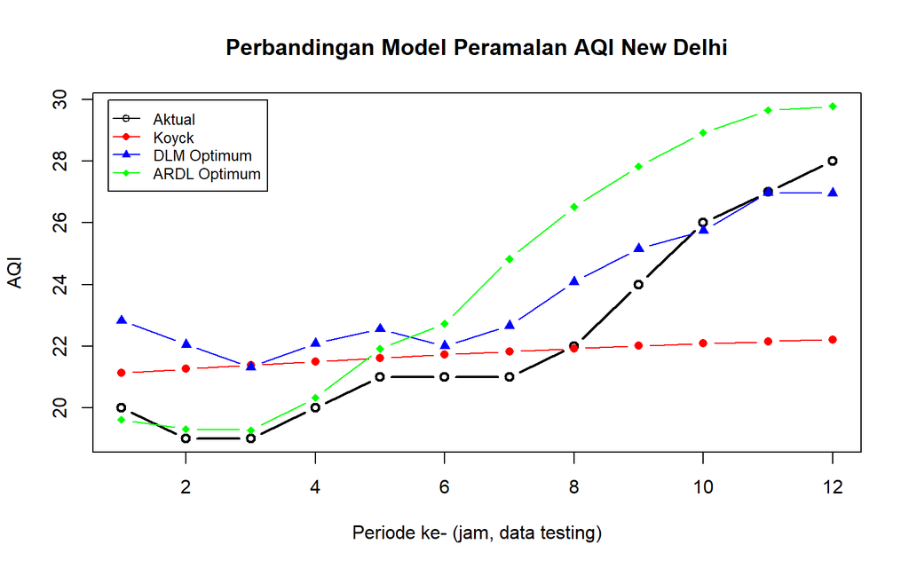

```r
waktu <- 1:nrow(test)

plot(waktu, test$Yt, type = "b", col = "black", lwd = 2, pch = 1,
     ylim = range(c(test$Yt, fore.koyck$forecasts, fore.dlm.opt$forecasts,
                     fore.ardl.opt$forecasts)),
     ylab = "AQI", xlab = "Periode ke- (jam, data testing)",
     main = "Perbandingan Model Peramalan AQI New Delhi")

lines(waktu, fore.koyck$forecasts, col = "red", type = "b", pch = 16)
lines(waktu, fore.dlm.opt$forecasts, col = "blue", type = "b", pch = 17)
lines(waktu, fore.ardl.opt$forecasts, col = "green", type = "b", pch = 18)

legend("topleft", legend = c("Aktual", "Koyck", "DLM Optimum", "ARDL Optimum"),
       col = c("black", "red", "blue", "green"), lty = 1,
       pch = c(1, 16, 17, 18), cex = 0.8, inset = 0.02)
```

# 7. Kesimpulan

Berdasarkan nilai MAPE pada Bagian 6, model dengan nilai MAPE terkecil dipilih sebagai model peramalan AQI New Delhi terbaik berbasis konsentrasi CO. Hasil uji asumsi pada Bagian 5 perlu dipertimbangkan bersamaan, model dengan akurasi peramalan terbaik namun melanggar asumsi klasik (autokorelasi, heteroskedastisitas, atau normalitas sisaan) memerlukan kehati-hatian tambahan dalam interpretasi inferensianya.